# RE: Telling a story from data

## Testing hypothesis

We are now interested in showing the relation between `Ozone` and the other covariates. We plot the distribution of ozone measurements within each month.

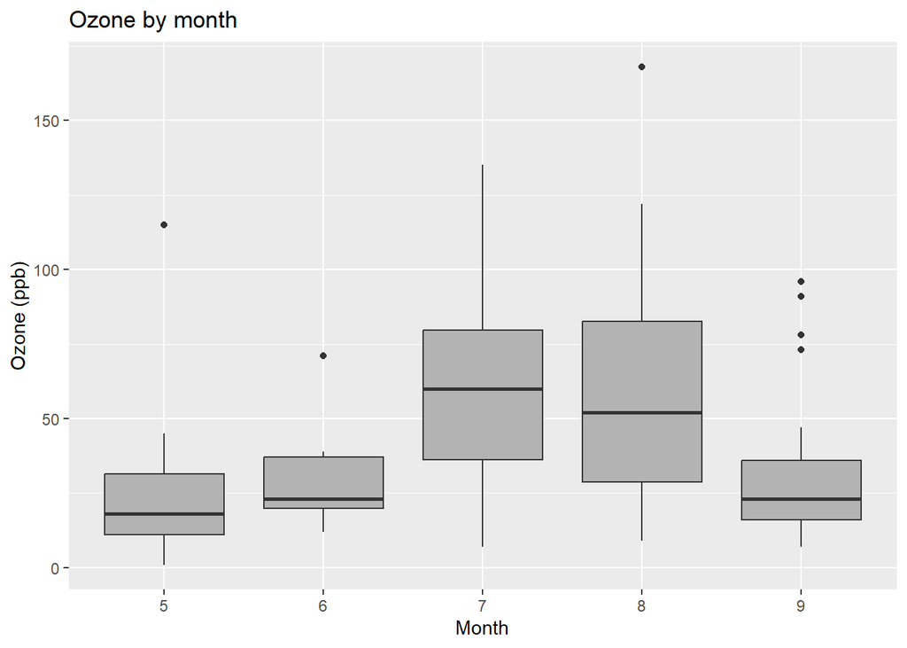

```r
plot <- ggplot(
  data = airquality,
  aes(x = Month, y = Ozone)) +
  geom_boxplot(fill = "grey70", na.rm = TRUE) + # Remove the NA values
  labs(title = "Ozone by month",
       x = "Month",
       y = "Ozone (ppb)")
plot
```

We see that ozone peaks in the summer months July and August. It seems reasonable that this is due to more sunlight and also higher temperature.

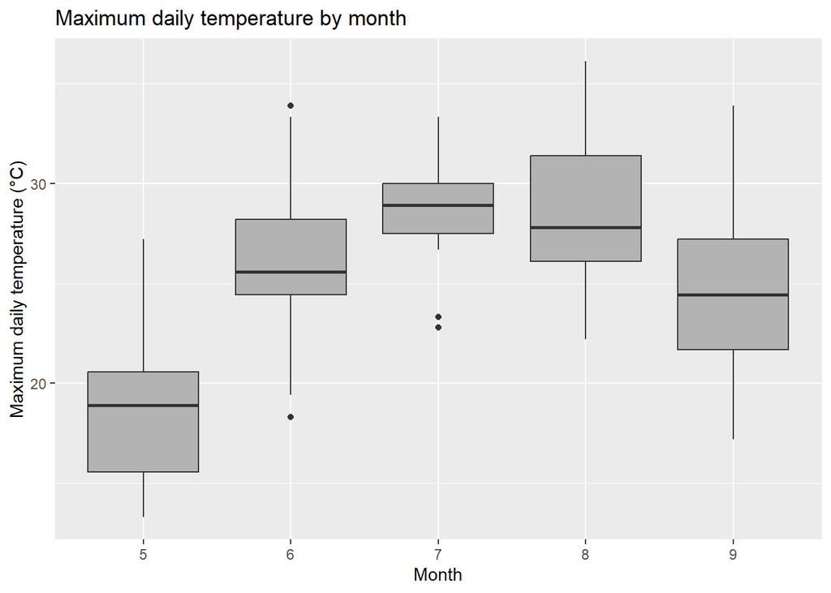

```r
plot <- ggplot(
  data = airquality,
  aes(x = Month, y = Temp_C)) +
  geom_boxplot(fill = "grey70", na.rm = TRUE) +
  labs(title = "Maximum daily temperature by month",
       x = "Month",
       y = "Maximum daily temperature (°C)")
plot
```

As expected, the temperatures by month boxplot looks very similar to the ozone by month boxplot.

Let us analyze two linear models with just one predictor for `Ozone`.

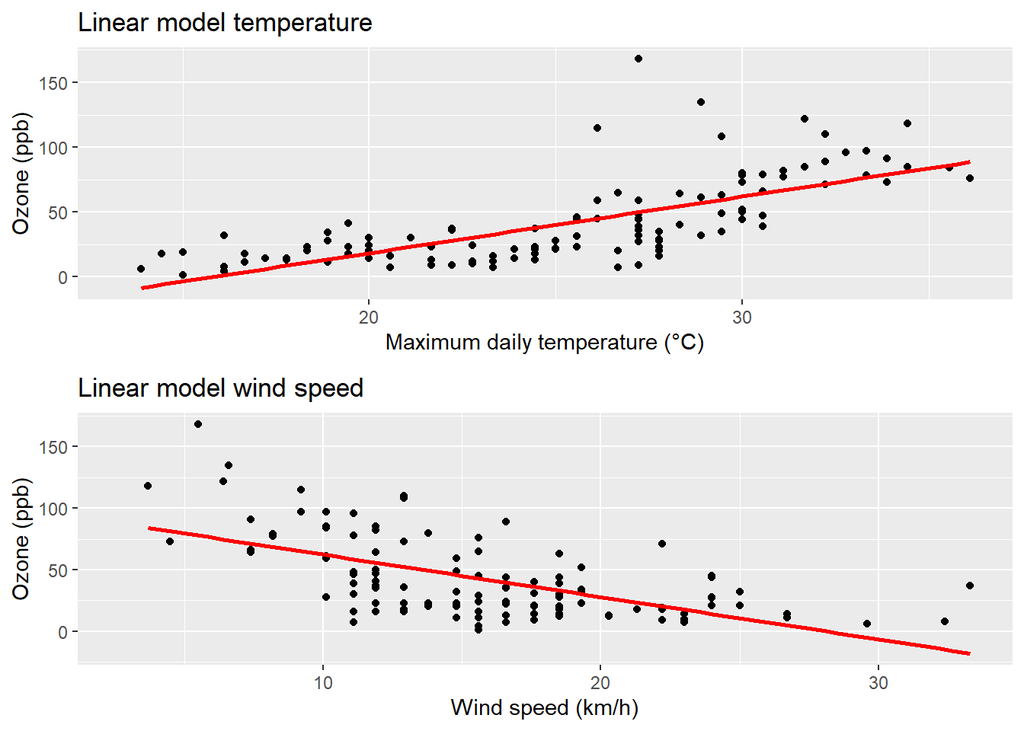

```r
plot_temp <- ggplot(
  airquality,
  aes(Temp_C, Ozone),
) +
  geom_point(na.rm = TRUE) +
  geom_smooth(formula = y ~ x, method = "lm", color = "red", se = F, na.rm = TRUE) +
  labs(x = "Maximum daily temperature (°C)",
       y = "Ozone (ppb)",
       title = "Linear model temperature")

plot_wind <- ggplot(
  airquality,
  aes(Wind_kmh, Ozone),
) +
  geom_point(na.rm = TRUE) +
  geom_smooth(formula = y ~ x, method = "lm", color = "red", se = F, na.rm = TRUE) +
  labs(x = "Wind speed (km/h)",
       y = "Ozone (ppb)",
       title = "Linear model wind speed"
       )

cowplot::plot_grid(plot_temp, plot_wind, nrow = 2)
```

We see that the linear models show a slope that we expected (positive for temperature and negative for wind speed). However, the model is too simple and does not capture the full relationship. With variable transformation, it could probably be improved but we did not cover it really until now, so let us keep the linear model but use multiple predictors.

```r
x <- c("Temp_C", "Solar.R", "Wind_kmh")
y <- "Ozone"

lin_mod <- lm(
  reformulate(x, y),
  data = airquality,
  na.action = na.omit,
)

lin_mod |> summary()
```

```
##
## Call:
## lm(formula = reformulate(x, y), data = airquality, na.action = na.omit)
##
## Residuals:
##    Min     1Q Median     3Q    Max
## -40.44 -14.23  -3.55  10.12  95.70
##
## Coefficients:
##              Estimate Std. Error t value Pr(>|t|)
## (Intercept) -11.50521   15.64102  -0.736   0.4636
## Temp_C        2.97361    0.45639   6.515 2.43e-09 ***
## Solar.R       0.05983    0.02319   2.580   0.0112 *
## Wind_kmh     -2.06890    0.40618  -5.093 1.52e-06 ***
## ---
## Signif. codes:  0 '***' 0.001 '**' 0.01 '*' 0.05 '.' 0.1 ' ' 1
##
## Residual standard error: 21.18 on 107 degrees of freedom
##   (42 Beobachtungen als fehlend gelöscht)
## Multiple R-squared:  0.6058, Adjusted R-squared:  0.5947
## F-statistic: 54.81 on 3 and 107 DF,  p-value: < 2.2e-16
```

**Comment** The coefficients have the sign that we expected and the p-value is also very small. So it is very unlikely that the variables have no true impact on `Ozone`.

The $R^2$ tells us that approximately 60 % of the variability in `Ozone` can be explained by `Wind_kmh`, `Temp_C` and `Solar.R`.

## Conclusion

The data confirmed our initial hypotheses that a higher temperature and solar radiation level generally increase the ozone concentration in New York. On the other hand, a higher wind speed decreases the ozone concentration in the city. However, it was difficult to get some robust results / models for `Ozone` because we are given so little data $\approx 150$ rows and many rows contain `NA` values. Also the data was measured 50 years ago and only in a single year (1973) which is not ideal.